# Arbeidskrav 3: Regression models

Johannes Urdahl Haugen

11/06/2020

### Introduksjon

Haun et al. (2019) samlet inn data fra 30 menn i høyskolealder for å se på effekten av styrketrening med høy motstand. Intervensjonen varte i 6 uker og så på hvordan ulike fysiologiske parametre endret seg. De 20 med lavest og høyest respons ble delt inn i to grupper, HIGH-responders og LOW-responders.

I denne oppgaven skal jeg se på korrelasjon mellom ulike variabler i datasettet. Del 1 vil omhandle en sammenligning av metodene t-test og regresjonsanalyse. I del 2 skal forskjellene mellom muskelstørrelse og muskelstyrke testes ved hjelp av regresjon- og korrelasjonsanalyse. I del 3 vil jeg prøve å estimere laktatterskelen til forsøkspersonene vi testet i starten av semesteret.

### Del 1: T-test og regresjonsanalyse

AVG_CSA_T1 er variabelen som skal testes. Dette er gjennomsnittet av tverrsnittsarealet i lårmuskulaturen ved pre-test hos forsøkspersonene i datasettet fra Haun et al. (2019). I denne delen av rapporten vil jeg sammenligne resultatet av en t-test og en regresjonsanalyse.

I disse testene er vi ute etter om det er en forskjell i tverrsnittsarealet mellom de to gruppene. Før vi gjennomfører t-testen kan vi sette opp to hypoteser. H0-hypotesen: Det er ikke en signifikant forskjell i tverrsnittsarealet mellom de to gruppene. H1-hypotesen: Det er en signifikant forskjell i tverrsnittsarealet mellom de to gruppene. Resultatet av t-testen vises i tabellen under.

| Tabell 1: Resultater t-test Variabel | Tabell 1: Resultater t-test Gruppe 1 | Tabell 1: Resultater t-test Gruppe 2 | Tabell 1: Resultater t-test Antall i gruppe 1 | Tabell 1: Resultater t-test Antall i gruppe 2 | Tabell 1: Resultater t-test P-verdi |
| --- | --- | --- | --- | --- | --- |
| AVG_CSA_T1 | HIGH | LOW | 10 | 10 | 0.013 |

T-testen ga en p-verdi på 0,013. Det vil si at det er en signifikant forskjell i tverrsnittsarealet mellom de to gruppene. Får vi samme resultatet ved en regresjonsmodell? Resultatet av regresjonsmodellen er presentert i tabellen under.

| Tabell 2: Resultater regresjonsmodell Term | Tabell 2: Resultater regresjonsmodell Estimat | Tabell 2: Resultater regresjonsmodell Standard Error | Tabell 2: Resultater regresjonsmodell T-statistic | Tabell 2: Resultater regresjonsmodell P-verdi |
| --- | --- | --- | --- | --- |
| Intercept | 3,588.428 | 244.388 | 14.683 | 0.000 |
| Cluster | 950.143 | 345.617 | 2.749 | 0.013 |

Regresjonsmodellen ga en p-verdi på 0,013. Dette var akkurat samme resultatet t-testen ga oss og konklusjonen blir den samme. Det er en signifikant forskjell i tverrsnittsarealet mellom de to gruppene. Vi kan også bruke størrelsen på standard error til å si noe om forskjellen i de to gruppene. Estimatet gir oss et tall nesten tre ganger høyere enn error-verdien og underbygger at det er en signifikant forskjell i datasettet.

### Del 2: Er det en sammenheng mellom muskelstyrke og muskelstørrelse?

Fra naturens side er det naturlig å anta at det er en klar sammenheng mellom muskelstyrke og muskelstørrelse. I denne delen skal vi forsøke å finne ut om det er en sammenheng mellom muskelstyrke og muskelstørrelse ved hjelp av datasettet fra Haun et al. (2019).

For å se på sammenhengen lager vi en regresjonsmodell. For å vise størrelsen på muskelstyrke bruker jeg variabelen “Squat_3RM_kg” og for å vise muskelstørrelse bruker jeg variabelen “AVG_CSA_T1”. I tillegg til muskelstørrelse har jeg tatt med kroppsvekt for å se om det er en forskjell mellom de to. Tabell 3 viser resultatene fra regresjonsmodellen. Figur 1 viser sammenhengen mellom muskelstyrke og tverrsnittsareal visuelt.

| Tabell 3: Resultater regresjonsmodell med konfidensintervall Term | Tabell 3: Resultater regresjonsmodell med konfidensintervall Estimat | Tabell 3: Resultater regresjonsmodell med konfidensintervall Standard Error | Tabell 3: Resultater regresjonsmodell med konfidensintervall T-Statistic | Tabell 3: Resultater regresjonsmodell med konfidensintervall P-verdi | Tabell 3: Resultater regresjonsmodell med konfidensintervall CI 2.5 % | Tabell 3: Resultater regresjonsmodell med konfidensintervall CI 97.5 % |
| --- | --- | --- | --- | --- | --- | --- |
| Intercept | 25.655 | 26.518 | 0.967 | 0.342 | -28.756 | 80.066 |
| Tverrsnittsareal | 0.003 | 0.003 | 0.841 | 0.408 | -0.004 | 0.010 |
| Kroppsvekt | 1.137 | 0.249 | 4.568 | 0.000 | 0.626 | 1.648 |

Regresjonsmodellen ga et stigningstall på 0.003. Det vil si at for hver enhet tverrsnittsarealet øker vil muskelstyrke gå opp med 0.003. Dette er et veldig lavt tall og gir ingen tydelig sammenheng mellom muskelstyrke og muskelstørrelse. Standard erroren er like stor som stigningstallet og underbygger sammen med p-verdien på 0,4 at det ikke er mulig å finne en klar sammenheng i dette datasettet. Figur 1 viser visuelt at sammenhengen mellom muskelstyrke og muskelstørrelse i dette datasettet er svak.

Ser vi på kroppsvekt derimot er det mulig å finne en sammenheng. Kroppsvekten ga et stigningstall på 1.137. Det vil si at for hver kg kroppsvekt en utøver går opp vil styrken øke med 1.137 kg. Standard erroren er lav og p-verdien godt under 0.05. Figur 2 viser sammenhengen mellom kroppsvekt og muskelstyrke.

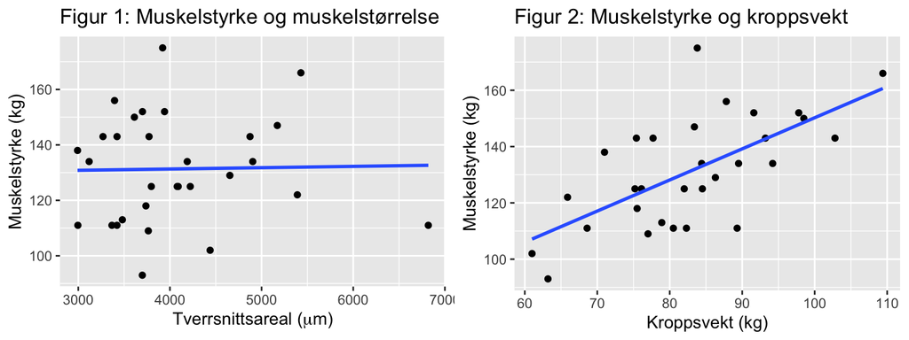